# Machine Learning: k-nearest neighbors algorithm and classification trees with C5.0 and CART

Bradley Richardson

10/01/2021

*The machine learning examples in this presentation will utilize the IRIS data set built into R and [kaggle’s](https://www.kaggle.com/mjamilmoughal/fruits-with-colors-dataset/version/1) ‘fruit with colors’ data set. Iris species will be predicted by sepal and petal dimensions, while fruit type will be predicted by weight, dimensions, and color score.*

#### **I. k-nearest neighbors**

*k*-nearest neighbors (KNN) is a supervised machine learning algorithm, utilizing a non-parametric classification method based on [Euclidean distance](https://en.wikipedia.org/wiki/Euclidean_distance) and a plurality among neighbors to make a prediction (ties are broken at random). KNN can also be used for regression, where the output is the average of values of *k*-nearest neighbors.

**Euclidean distance:**

[figure not shown]

Summary of the IRIS data set:

```r
summary(iris)
```

```
##   Sepal.Length    Sepal.Width     Petal.Length    Petal.Width
##  Min.   :4.300   Min.   :2.000   Min.   :1.000   Min.   :0.100
##  1st Qu.:5.100   1st Qu.:2.800   1st Qu.:1.600   1st Qu.:0.300
##  Median :5.800   Median :3.000   Median :4.350   Median :1.300
##  Mean   :5.843   Mean   :3.057   Mean   :3.758   Mean   :1.199
##  3rd Qu.:6.400   3rd Qu.:3.300   3rd Qu.:5.100   3rd Qu.:1.800
##  Max.   :7.900   Max.   :4.400   Max.   :6.900   Max.   :2.500
##        Species
##  setosa    :50
##  versicolor:50
##  virginica :50
##
##
##
```

We’ll normalize the data between 0 and 1 to give each feature equal importance:

```r
normalize <- function(x) {
  return((x - min(x)) / (max(x) - min(x)))
}
```

Normalize the IRIS data then verify results:

```r
irisNormal <- iris
irisNormal[,1:4] <- as.data.frame(lapply(iris[,1:4],normalize))
summary(irisNormal)
```

```
##   Sepal.Length     Sepal.Width      Petal.Length     Petal.Width
##  Min.   :0.0000   Min.   :0.0000   Min.   :0.0000   Min.   :0.00000
##  1st Qu.:0.2222   1st Qu.:0.3333   1st Qu.:0.1017   1st Qu.:0.08333
##  Median :0.4167   Median :0.4167   Median :0.5678   Median :0.50000
##  Mean   :0.4287   Mean   :0.4406   Mean   :0.4675   Mean   :0.45806
##  3rd Qu.:0.5833   3rd Qu.:0.5417   3rd Qu.:0.6949   3rd Qu.:0.70833
##  Max.   :1.0000   Max.   :1.0000   Max.   :1.0000   Max.   :1.00000
##        Species
##  setosa    :50
##  versicolor:50
##  virginica :50
##
##
##
```

Create the IRIS training and testing data:

```r
irisLabels <- iris[,5] # remember the original species labels
set.seed(1234) # for reproducibility
# indexes of random sample representing 75% of original data
irisIndex <- sample(nrow(irisNormal), size = floor(0.75 * nrow(irisNormal)))
trainingData <- irisNormal[irisIndex,1:4] # training data
trainingLabels <- irisNormal[irisIndex,5] # labels for the training data
testingData <- irisNormal[-irisIndex,1:4] # testing data 25% of original data
testingLabels <- irisLabels[-irisIndex] # labels for testing data
```

Visualize our data:

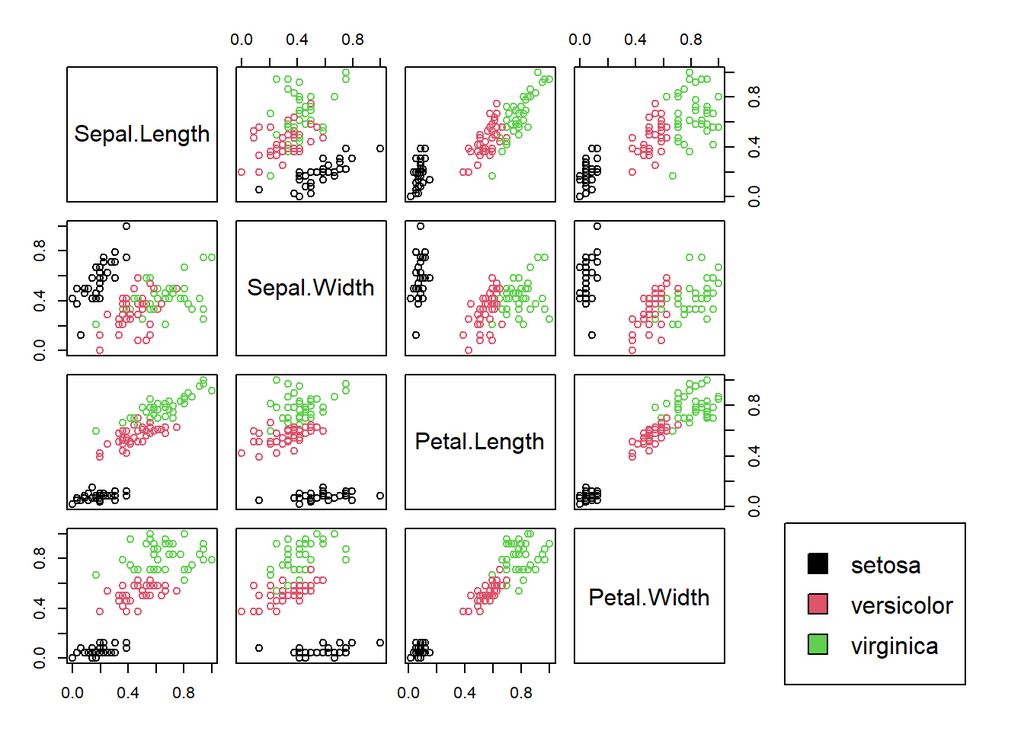

```r
trainReference <- cbind(trainingData,trainingLabels) # training data frame
# scatterplot matrix for training data, a look at our neighbors
pairs(trainReference[,1:4], col = trainReference[,5], oma=c(3,3,3,15))
par(xpd = TRUE)
legend("bottomright", fill = unique(trainReference[,5]),
       legend = c(levels(trainReference[,5])))
```

*k*-nearest neighbor with IRIS:

```r
# make sure k is odd
k1 <- round(sqrt(nrow(trainingData)))
if ((k1 %% 2) == 0) {k1 <- k1 + 1}
irisPrediction1 <- knn(train=trainingData, # training data
                      test=testingData, # testing data
                      cl=trainingLabels, # training labels
                      k=k1) # how many neighbors
pander(table(testingLabels,irisPrediction1)) # confusion matrix
```

|  | setosa | versicolor | virginica |
| --- | --- | --- | --- |
| **setosa** | 15 | 0 | 0 |
| **versicolor** | 0 | 12 | 0 |
| **virginica** | 0 | 1 | 10 |

The above rows represent the true classification of the test data and the columns represent the prediction. Note only 1 failed prediction.

What was the accuracy?

```r
cf1 <- confusionMatrix(testingLabels,irisPrediction1)
print(paste(signif(cf1$overall[1],digits=3)*100,"% accurate."))
```

```
## [1] "97.4 % accurate."
```

KNN again, this time with fruit:

```r
fruit <- as.data.frame(read.delim("fruit_data_with_colors.txt"))
fruit <- fruit[,c(2,4,5,6,7)] # selecting specific columns
summary(fruit)
```

```
##   fruit_name             mass           width           height
##  Length:59          Min.   : 76.0   Min.   :5.800   Min.   : 4.000
##  Class :character   1st Qu.:140.0   1st Qu.:6.600   1st Qu.: 7.200
##  Mode  :character   Median :158.0   Median :7.200   Median : 7.600
##                     Mean   :163.1   Mean   :7.105   Mean   : 7.693
##                     3rd Qu.:177.0   3rd Qu.:7.500   3rd Qu.: 8.200
##                     Max.   :362.0   Max.   :9.600   Max.   :10.500
##   color_score
##  Min.   :0.5500
##  1st Qu.:0.7200
##  Median :0.7500
##  Mean   :0.7629
##  3rd Qu.:0.8100
##  Max.   :0.9300
```

Normalize fruit and verify:

```r
fruitNormal <- fruit
fruitNormal[,2:5] <- as.data.frame(lapply(fruit[,2:5],normalize))
summary(fruitNormal)
```

```
##   fruit_name             mass            width            height
##  Length:59          Min.   :0.0000   Min.   :0.0000   Min.   :0.0000
##  Class :character   1st Qu.:0.2238   1st Qu.:0.2105   1st Qu.:0.4923
##  Mode  :character   Median :0.2867   Median :0.3684   Median :0.5538
##                     Mean   :0.3046   Mean   :0.3434   Mean   :0.5682
##                     3rd Qu.:0.3531   3rd Qu.:0.4474   3rd Qu.:0.6462
##                     Max.   :1.0000   Max.   :1.0000   Max.   :1.0000
##   color_score
##  Min.   :0.0000
##  1st Qu.:0.4474
##  Median :0.5263
##  Mean   :0.5602
##  3rd Qu.:0.6842
##  Max.   :1.0000
```

Create the fruit training and testing data:

```r
fruitLabels <- fruit[,1] # remember the original fruit labels
set.seed(1234) # for reproducibility
# indexes of random sample representing 75% of original data
fruitIndex <- sample(nrow(fruitNormal), size = floor(0.75 * nrow(fruitNormal)))
trainingData2 <- fruitNormal[fruitIndex,2:5] # training data
trainingLabels2 <- fruitNormal[fruitIndex,1] # labels for the training data
testingData2 <- fruitNormal[-fruitIndex,2:5] # testing data 25% of original data
testingLabels2 <- factor(fruitLabels[-fruitIndex]) # labels for testing data
```

Visualize the data:

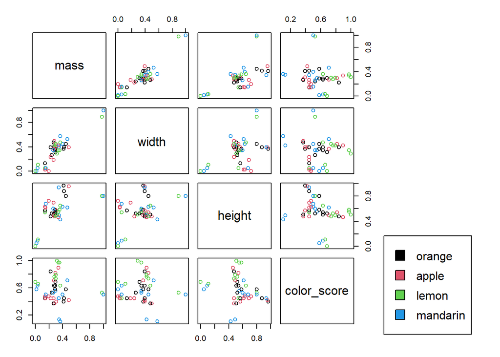

```r
trainReference2 <- cbind(trainingData2,trainingLabels2) # training data frame
# scatterplot matrix for training data, a look at our neighbors
pairs(trainReference2[,1:4], col = c(1:4), oma=c(3,3,3,15))
par(xpd = TRUE)
legend("bottomright", fill = c(1:4),
       legend = c(unique(trainReference2[,5])))
```

*k*-nearest neighbor with fruit, confusion matrix:

```r
# make sure k is odd
k2 <- round(sqrt(nrow(trainingData2)))
if ((k2 %% 2) == 0) {k2 <- k2 + 1}
fruitPrediction1 <- knn(train=trainingData2,# training data
                      test=testingData2,  # testing data
                      cl=trainingLabels2,  # training labels
                      k=k2) # how many neighbors
pander(table(testingLabels2,fruitPrediction1)) # confusion matrix
```

|  | apple | lemon | mandarin | orange |
| --- | --- | --- | --- | --- |
| **apple** | 4 | 0 | 0 | 1 |
| **lemon** | 0 | 5 | 0 | 0 |
| **mandarin** | 0 | 0 | 1 | 0 |
| **orange** | 0 | 0 | 0 | 4 |

The above rows represent the true classification of the test data and the columns represent the prediction. Again, only 1 failed prediction.

What was the accuracy?

```r
cf2 <- confusionMatrix(testingLabels2,fruitPrediction1)
print(paste(signif(cf2$overall[1],digits=3)*100,"% accurate."))
```

```
## [1] "93.3 % accurate."
```

# **II. C5.0 classification tree model**

C5.0 is a supervised machine learning algorithm, developed by Ross Quinlan, used to generate decision trees. [Information entropy](https://en.wikipedia.org/wiki/Entropy_%28information_theory%29) is computed as a value which determines optimal splits of purer classes in the data.

C5.0 with IRIS:

```r
model1 <- C5.0(iris[irisIndex,1:4],iris[irisIndex,5])
summary(model1)
```

```
##
## Call:
## C5.0.default(x = iris[irisIndex, 1:4], y = iris[irisIndex, 5])
##
##
## C5.0 [Release 2.07 GPL Edition]      Wed Oct 06 10:59:24 2021
## -------------------------------
##
## Class specified by attribute `outcome'
##
## Read 112 cases (5 attributes) from undefined.data
##
## Decision tree:
##
## Petal.Width <= 0.4: setosa (35)
## Petal.Width > 0.4:
## :...Petal.Width > 1.6: virginica (37/1)
##     Petal.Width <= 1.6:
##     :...Petal.Length <= 4.9: versicolor (36)
##         Petal.Length > 4.9: virginica (4/1)
##
##
## Evaluation on training data (112 cases):
##
##      Decision Tree
##    ----------------
##    Size      Errors
##
##       4    2( 1.8%)   <<
##
##
##     (a)   (b)   (c)    <-classified as
##    ----  ----  ----
##      35                (a): class setosa
##            36     2    (b): class versicolor
##                  39    (c): class virginica
##
##
##  Attribute usage:
##
##  100.00% Petal.Width
##   35.71% Petal.Length
##
##
## Time: 0.0 secs
```

C5.0 classification tree for IRIS:

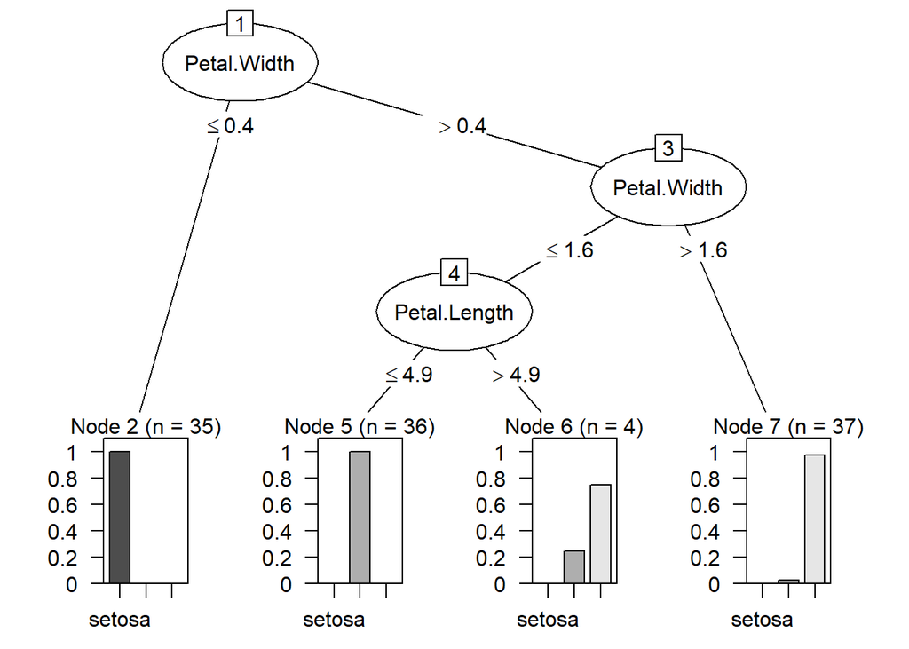

```r
plot(model1)
```

Confusion matrix:

```r
irisPrediction2 <- predict(model1, iris[-irisIndex,1:4])
pander(table(iris[-irisIndex,5],irisPrediction2))
```

|  | setosa | versicolor | virginica |
| --- | --- | --- | --- |
| **setosa** | 13 | 2 | 0 |
| **versicolor** | 0 | 11 | 1 |
| **virginica** | 0 | 0 | 11 |

What was the accuracy?

```r
cf3 <- confusionMatrix(iris[-irisIndex,5],irisPrediction2)
print(paste(signif(cf3$overall[1],digits=3)*100,"% accurate."))
```

```
## [1] "92.1 % accurate."
```

C5.0 with fruit:

```r
model2 <- C5.0(fruit[fruitIndex,2:5],factor(fruit[fruitIndex,1]))
summary(model2)
```

```
##
## Call:
## C5.0.default(x = fruit[fruitIndex, 2:5], y = factor(fruit[fruitIndex, 1]))
##
##
## C5.0 [Release 2.07 GPL Edition]      Wed Oct 06 10:59:24 2021
## -------------------------------
##
## Class specified by attribute `outcome'
##
## Read 44 cases (5 attributes) from undefined.data
##
## Decision tree:
##
## width <= 6.5:
## :...height <= 4.7: mandarin (4)
## :   height > 4.7: lemon (7)
## width > 6.5:
## :...height > 9.2: lemon (4)
##     height <= 9.2:
##     :...color_score > 0.82: apple (9)
##         color_score <= 0.82:
##         :...color_score <= 0.71: apple (5)
##             color_score > 0.71: orange (15)
##
##
## Evaluation on training data (44 cases):
##
##      Decision Tree
##    ----------------
##    Size      Errors
##
##       6    0( 0.0%)   <<
##
##
##     (a)   (b)   (c)   (d)    <-classified as
##    ----  ----  ----  ----
##      14                      (a): class apple
##            11                (b): class lemon
##                   4          (c): class mandarin
##                        15    (d): class orange
##
##
##  Attribute usage:
##
##  100.00% width
##  100.00% height
##   65.91% color_score
##
##
## Time: 0.0 secs
```

C5.0 classification tree for fruit:

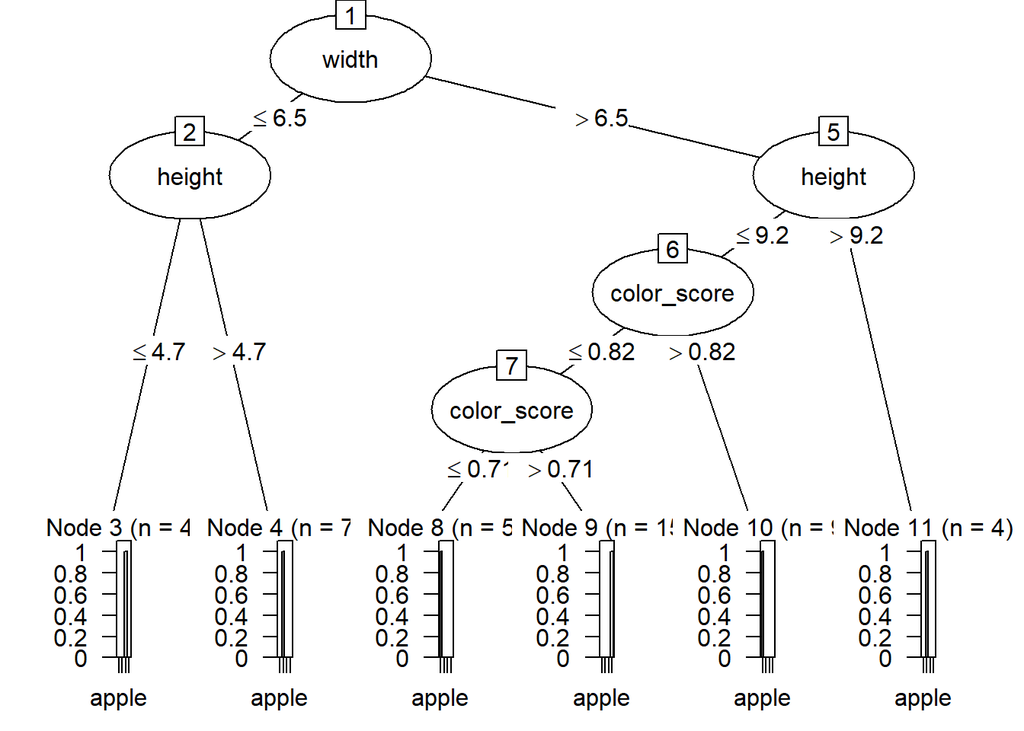

```r
plot(model2)
```

Confusion Matrix:

```r
fruitPrediction2 <- predict(model2, fruit[-fruitIndex,2:5])
pander(table(fruit[-fruitIndex,1],fruitPrediction2))
```

|  | apple | lemon | mandarin | orange |
| --- | --- | --- | --- | --- |
| **apple** | 4 | 0 | 0 | 1 |
| **lemon** | 0 | 4 | 0 | 1 |
| **mandarin** | 0 | 0 | 1 | 0 |
| **orange** | 0 | 1 | 0 | 3 |

What was the accuracy?

```r
cf4 <- confusionMatrix(factor(fruit[-fruitIndex,1]),fruitPrediction2)
print(paste(signif(cf4$overall[1],digits=3)*100,"% accurate."))
```

```
## [1] "80 % accurate."
```

# **III. Recursive partitioning classification tree model**

CART is another supervised machine learning algorithm, developed by Leo Breiman, J. H. Friedman, R. A. Olshen, and C. J. Stone, used to generate decision trees. A computed [Gini coefficient](https://en.wikipedia.org/wiki/Gini_coefficient) is computed and minimized to determine optimal splits in the data.

Recursive partitioning with IRIS:

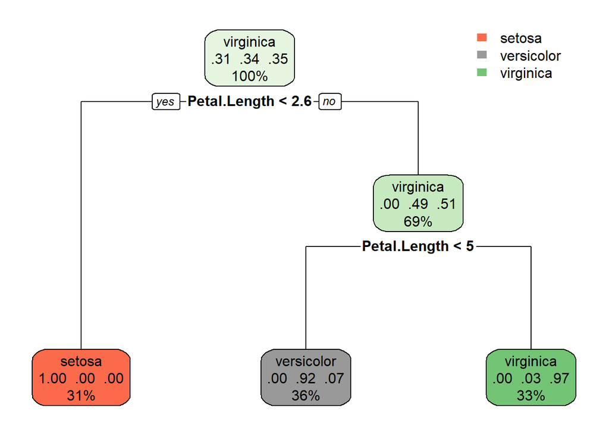

```r
model3 <- rpart(Species ~ ., data=iris[irisIndex,],method="class")
rpart.plot(model3)
```

Confusion matrix:

```r
irisPrediction3 <- predict(model3, iris[-irisIndex,],type="class")
pander(table(testingLabels,irisPrediction3))
```

|  | setosa | versicolor | virginica |
| --- | --- | --- | --- |
| **setosa** | 15 | 0 | 0 |
| **versicolor** | 0 | 11 | 1 |
| **virginica** | 0 | 3 | 8 |

What was the accuracy?

```r
cf5 <- confusionMatrix(iris[-irisIndex,5],irisPrediction3)
print(paste(signif(cf5$overall[1],digits=3)*100,"% accurate."))
```

```
## [1] "89.5 % accurate."
```

Recursive partitioning with fruit:

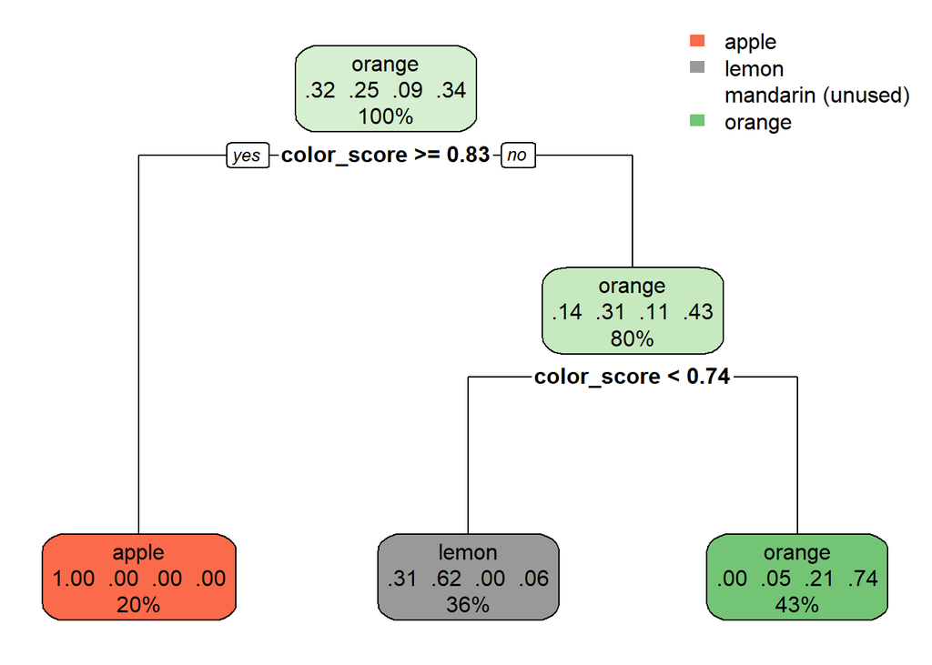

```r
model4 <- rpart(fruit_name ~ .,
                data=fruit[fruitIndex,], method="class")
par(mar = c(5.1, 4.1, 4.1, 2.1))
rpart.plot(model4,legend.x=.75)
```

Mandarin was not used in the classification tree above.

Confusion matrix:

```r
fruitPrediction3 <- predict(model4, fruit[-fruitIndex,],type="class")
pander(table(fruit[-fruitIndex,1],fruitPrediction3))
```

|  | apple | lemon | mandarin | orange |
| --- | --- | --- | --- | --- |
| **apple** | 2 | 3 | 0 | 0 |
| **lemon** | 0 | 5 | 0 | 0 |
| **mandarin** | 0 | 0 | 0 | 1 |
| **orange** | 0 | 0 | 0 | 4 |

What was the accuracy?

```r
cf6 <- confusionMatrix(testingLabels2,fruitPrediction3)
print(paste(signif(cf6$overall[1],digits=3)*100,"% accurate."))
```

```
## [1] "73.3 % accurate."
```

**References:**

[Fruit with colors dataset](https://www.kaggle.com/mjamilmoughal/fruits-with-colors-dataset/version/1)

[R Documentation - knn()](https://www.rdocumentation.org/packages/class/versions/7.3-19/topics/knn)

[Analytics Vidhya - Best way to learn kNN Algorithm using R](https://www.analyticsvidhya.com/blog/2015/08/learning-concept-knn-algorithms-programming/)

[towards data science - K-nearest Neighbors Algorithm](https://towardsdatascience.com/k-nearest-neighbors-algorithm-with-examples-in-r-simply-explained-knn-1f2c88da405c)

[StackExchange - Which type of data normalizing should be used with KNN?](https://stats.stackexchange.com/questions/363889/which-type-of-data-normalizing-should-be-used-with-knn)

[R Documentation - C5.0()](https://www.rdocumentation.org/packages/C50/versions/0.1.5/topics/C5.0.default)

[CRAN - Classification Models](https://cran.r-project.org/web/packages/C50/vignettes/C5.0.html)

[Mercury Webster - Classification of data using decision tree and regression tree methods](http://mercury.webster.edu/aleshunas/R_learning_infrastructure/Classification%20of%20data%20using%20decision%20tree%20and%20regression%20tree%20methods.html)

[R Documentation - rpart()](https://www.rdocumentation.org/packages/rpart/versions/4.1-15/topics/rpart)

[Quick-R - Tree-Based Models](https://www.statmethods.net/advstats/cart.html)

[Pluralsight - Explore R Libraries: Rpart](https://www.pluralsight.com/guides/explore-r-libraries:-rpart)